# Notebook

## **Python Basics, Lists, Strings, Dictionaries, File Handling, Statistics, and Flow Control**

## Question 1 : List Operations and Basic Statistics:

- Create a list of the first 20 natural numbers.

-Compute the sum of all even numbers in the list.

-Compute the product of all odd numbers in the list.

-Calculate the mean, median, and standard deviation of the list.

```python
import statistics
import math

natural_numbers = list(range(1, 21))

even_sum = sum(num for num in natural_numbers if num % 2 == 0)

odd_product = math.prod(num for num in natural_numbers if num % 2 != 0)

mean = statistics.mean(natural_numbers)
median = statistics.median(natural_numbers)
std_dev = statistics.stdev(natural_numbers)

print(f"Sum of even numbers: {even_sum}")
print(f"Product of odd numbers: {odd_product}")
print(f"Mean: {mean}")
print(f"Median: {median}")
print(f"Standard Deviation: {std_dev}")
```

```
Sum of even numbers: 110
Product of odd numbers: 654729075
Mean: 10.5
Median: 10.5
Standard Deviation: 5.916079783099616
```

## Question 2: Mutable vs. Immutable Data Types:

- Explain the difference between mutable and immutable data types in Python. Provide examples of each

### Immutable Data Types

The Immutable data types in python are those that can never change their values in place.This means that the one particular memeory address will be storing only one value at a time. If a varibale is assigned to these data types , then these values can not be changed during the whole execution of program.

In python variable neames are just the references to the value-objects, that is, data values. The variable name do not store values themselves, they are not storage containers.variables act as references to objects, not as containers that directly hold values. This is why when we assign a value to a variable, we actually assigning a reference to the memory location where the value is stored. The immutable data types in Python are those that cannot be modified after they are created. If an operation tries to modify the value, it will create a new object, leaving the original object unchanged.

- The Immutable data types in python includes:

  (1) Integers

  (2) Floating Point Numbers

  (3) Strings

  (4) Tuples

  (5) Bools

```python
print("Immutable data types in python")

print("Integers are immutable data types in python")
x = 10
print(id(x))  # Shows the memory address of x
x = x + 5      # A new object is created because integers are immutable
print(id(x))  # Shows a different memory address
print(x)

print("Strings are immutable data types in python")
name = "Alice"
print(id(name))  # Shows the memory address of name
name = name + " Wonderland"  # Creates a new string object
print(id(name))  # Shows a different memory address
print(name)

print("Tuples are immutable data types in python")
my_tuple = (1, 2, 3)
print(id(my_tuple))
print(my_tuple)
```

```
Immutable data types in python
Integers are immutable data types in python
140295639876112
140295639876272
15
Strings are immutable data types in python
140294857181808
140294383564432
Alice Wonderland
Tuples are immutable data types in python
140294257749376
(1, 2, 3)
```

### Mutable Data Types

The mutable data types are those whose values can be changed in place. This means that objects of mutable types can have their values modified after they are created. Unlike immutable types, when a mutable object is modified, the change affects the original object in memory.

Thses are mutable data types in python:

```
(1) Lists

(2) Sets

(3) Dictionary
```

```python
my_list = [1, 2, 3]
print("Original List:", my_list)
my_list[1] = 10
print("After Modification:", my_list)
print("list is modified,hence list is mutable data type in python")

my_dict = {"name": "Alice", "age": 25}
print("Original Dictionary:", my_dict)
my_dict["age"] = 26
print("After Modification:", my_dict)
print("Dictionary is mutable data type in python")

my_set = {1, 2, 3}
print("Original Set:", my_set)
my_set.add(4)
print("After Modification:", my_set)
print("Set is mutable data type in python")
```

```
Original List: [1, 2, 3]
After Modification: [1, 10, 3]
list is modified,hence list is mutable data type in python
Original Dictionary: {'name': 'Alice', 'age': 25}
After Modification: {'name': 'Alice', 'age': 26}
Dictionary is mutable data type in python
Original Set: {1, 2, 3}
After Modification: {1, 2, 3, 4}
Set is mutable data type in python
```

## Question 3 Fibonacci Sequence:

- Write a Python function that takes a number n and returns a list of the first n Fibonacci numbers.
- Plot the Fibonacci sequence using a line graph.

```
First 30 Fibonacci numbers: [0, 1, 1, 2, 3, 5, 8, 13, 21, 34, 55, 89, 144, 233, 377, 610, 987, 1597, 2584, 4181, 6765, 10946, 17711, 28657, 46368, 75025, 121393, 196418, 317811, 514229]
```

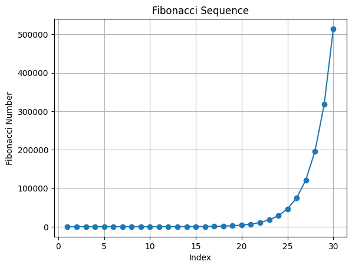

```python
import matplotlib.pyplot as plt

def generate_fibonacci(n):
    if n <= 0:
        return []
    fibonacci = [0, 1]
    for _ in range(2, n):
        fibonacci.append(fibonacci[-1] + fibonacci[-2])
    return fibonacci[:n]

def plot_fibonacci(n):
    fibonacci = generate_fibonacci(n)
    plt.plot(range(1, n + 1), fibonacci, marker='o')
    plt.title("Fibonacci Sequence")
    plt.xlabel("Index")
    plt.ylabel("Fibonacci Number")
    plt.grid()
    plt.show()


n = 30
fibonacci_sequence = generate_fibonacci(n)
print(f"First {n} Fibonacci numbers: {fibonacci_sequence}")
plot_fibonacci(n)
```

## Question 4 List Manipulation:

Given a list [3, 5, 7, 9, 11, 13]:

- Insert 6 at the 3rd index.
- Remove the number 7 from the list.
- Reverse the list.
- Calculate the mean and median of the modified list.

```python
import statistics


numbers = [3, 5, 7, 9, 11, 13]
numbers.insert(3, 6)
numbers.remove(7)
numbers.reverse()

mean = statistics.mean(numbers)
median = statistics.median(numbers)

print(f"Modified list: {numbers}")
print(f"Mean: {mean}")
print(f"Median: {median}")
```

```
Modified list: [13, 11, 9, 6, 5, 3]
Mean: 7.833333333333333
Median: 7.5
```

## Question 5 User Input and Basic Statistics:

- Write a program to read a comma-separated list of numbers from the user (e.g., “10, 20, 30, 40”).
- Calculate the mean of the numbers.
- Identify and print the smallest and largest numbers.
- Plot a histogram of the numbers.

[output not shown]

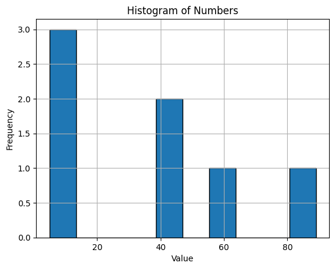

```python
import statistics
import matplotlib.pyplot as plt

user_input = input("Enter a comma-separated list of numbers ")
numbers = [float(num) for num in user_input.split(',')]

mean = statistics.mean(numbers)
smallest = min(numbers)
largest = max(numbers)

print(f"Numbers: {numbers}")
print(f"Mean: {mean}")
print(f"Smallest number: {smallest}")
print(f"Largest number: {largest}")

plt.hist(numbers, bins=10, edgecolor='black')
plt.title("Histogram of Numbers")
plt.xlabel("Value")
plt.ylabel("Frequency")
plt.grid(True)
plt.show()
```

## Question 6: Palindrome Check:

- Write a program to check if a string is a palindrome (ignoring spaces and case).

  Input: "A man a plan a canal Panama"

  Output: True

```python
def is_palindrome(s):
    cleaned = ''.join(char.lower() for char in s if char.isalnum())
    return cleaned == cleaned[::-1]

input_string = input("Enter a string to check if it is a palindrome: ")
print(f"Output:-{is_palindrome(input_string)}")
```

```
Enter a string to check if it is a palindrome:  A man a plan a canal Panama
Output:-True
```

## Question 7: Dictionary Operations:

- Create a dictionary of student names (keys) and their marks (values).
- Compute the average marks.
- Print the names of students scoring above the average.
- Visualize the distribution of marks using a bar chart.

```
Average Marks: 72
Students scoring above average:
varun
kartik
```

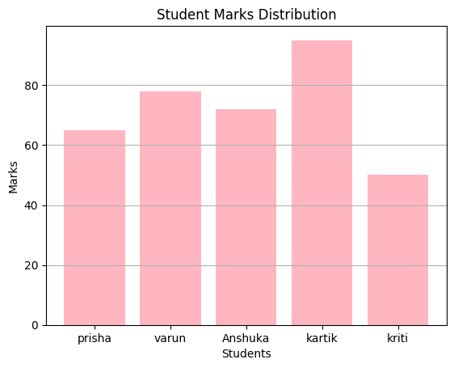

```python
student_marks = {
    "prisha": 65,
    "varun": 78,
    "Anshuka": 72,
    "kartik": 95,
    "kriti": 50
}

average_marks = statistics.mean(student_marks.values())

print(f"Average Marks: {average_marks}")
print("Students scoring above average:")
for student, marks in student_marks.items():
    if marks > average_marks:
        print(student)

plt.bar(student_marks.keys(), student_marks.values(), color='lightpink')
plt.title("Student Marks Distribution")
plt.xlabel("Students")
plt.ylabel("Marks")
plt.grid(axis='y')
plt.show()
```

## Question 8:Tuple List Creation:

- Create a list of tuples, where each tuple contains a number and its square (e.g., [(1, 1), (2, 4), (3, 9), ...] for numbers 1 to 10).
- Plot the numbers and their squares on a scatter plot.

```
List of numbers and their squares: [(1, 1), (2, 4), (3, 9), (4, 16), (5, 25), (6, 36), (7, 49), (8, 64), (9, 81), (10, 100)]
```

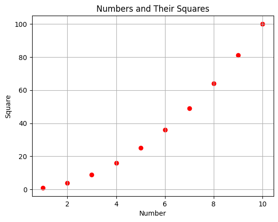

```python
n = 10
number_square_list = [(i, i**2) for i in range(1, n + 1)]

print(f"List of numbers and their squares: {number_square_list}")

numbers, squares = zip(*number_square_list)
plt.scatter(numbers, squares, color='red')
plt.title("Numbers and Their Squares")
plt.xlabel("Number")
plt.ylabel("Square")
plt.grid(True)
plt.show()
```

## Question 9: Merging Dictionaries:

- Write Python code to merge two dictionaries. If a key is present in both, sum their values.

  Example:

  dict1 = {'a': 10, 'b': 20}

  dict2 = {'b': 5, 'c': 15}

  Output: {'a': 10, 'b': 25, 'c': 15}

```python
dict1 = {'a': 10, 'b': 20}
dict2 = {'b': 5, 'c': 15}

merged_dict = dict1.copy()
for key, value in dict2.items():
    merged_dict[key] = merged_dict.get(key, 0) + value

print(merged_dict)
```

```
{'a': 10, 'b': 25, 'c': 15}
```

## Question 10: Character Frequency:

Write a function that accepts a string and:

```
Converts all characters to lowercase.
Counts the frequency of each character.
Returns a dictionary with characters as keys and their counts as values.
Visualize the character frequencies using a bar chart.
```

```
Enter a string: heLLO WOrld
Counter({'l': 3, 'o': 2, 'h': 1, 'e': 1, ' ': 1, 'w': 1, 'r': 1, 'd': 1})
```

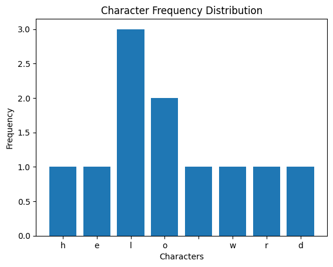

```python
import matplotlib.pyplot as plt
from collections import Counter

def character_frequency(text):
    text = text.lower()
    char_count = Counter(text)
    return char_count

def visualize_frequency(char_count):
    characters = list(char_count.keys())
    frequencies = list(char_count.values())
    plt.bar(characters, frequencies)
    plt.xlabel('Characters')
    plt.ylabel('Frequency')
    plt.title('Character Frequency Distribution')
    plt.show()

text = input("Enter a string: ")
char_count = character_frequency(text)
print(char_count)
visualize_frequency(char_count)
```

## Question 11: Remove Duplicates:

- Write a program to remove duplicate elements from a list while maintaining the order of elements.
- Calculate the mean and median of the unique elements.

```python
from statistics import mean, median
import math

def remove_duplicates(input_list):
    unique_elements = []
    seen = set()
    for element in input_list:
        if element not in seen:
            unique_elements.append(element)
            seen.add(element)

    mean_value = mean(unique_elements) if unique_elements else None
    median_value = median(unique_elements) if unique_elements else None

    return unique_elements, mean_value, median_value

input_list = [4, 5, 6, 4, 2, 5, 3, 2, 8]
unique_elements, mean_value, median_value = remove_duplicates(input_list)

print(f"Unique Elements: {unique_elements}")
print(f"Mean of Unique Elements: {mean_value}")
print(f"Median of Unique Elements: {median_value}")
```

```
Unique Elements: [4, 5, 6, 2, 3, 8]
Mean of Unique Elements: 4.666666666666667
Median of Unique Elements: 4.5
```

## Question 12: String Operations:

- Given a list of strings, write a Python function to:
  - Find the longest string.
  - Count how many strings start with a vowel.
  - Visualize the distribution of string lengths using a histogram.

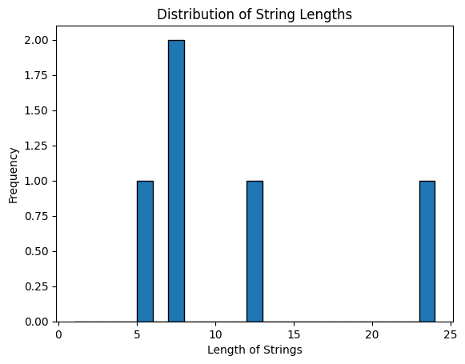

```
Longest String: Artificial Intelligence
Number of Strings Starting with a Vowel: 2
```

```python
import matplotlib.pyplot as plt

def find_strings(strings):
    longest_string = max(strings, key=len) if strings else None
    vowels = {'a', 'e', 'i', 'o', 'u', 'A', 'E', 'I', 'O', 'U'}
    count_starts_with_vowel = sum(1 for s in strings if s and s[0] in vowels)

    string_lengths = [len(s) for s in strings]
    plt.hist(string_lengths, bins=range(1, max(string_lengths) + 2), edgecolor='black')
    plt.title('Distribution of String Lengths')
    plt.xlabel('Length of Strings')
    plt.ylabel('Frequency')
    plt.show()

    return longest_string, count_starts_with_vowel

strings = ["Maths","English","Artificial Intelligence","Data Science","History"]
longest_string, count_starts_with_vowel = find_strings(strings)
print(f"Longest String: {longest_string}")
print(f"Number of Strings Starting with a Vowel: {count_starts_with_vowel}")
```

## Question 13: Sorting Dictionaries:

- Write a function to sort a list of dictionaries by a key.

  Example: data = [{'name': 'Alice', 'age': 25}, {'name': 'Bob', 'age': 22}] Sort by age → [{'name': 'Bob', 'age': 22}, {'name': 'Alice', 'age': 25}]

```python
def sort(dict,key):
    sorted_data = sorted(dict, key=lambda x: x[key])
    return sorted_data

dict = [
        {'name': 'Alice', 'age': 25},
        {'name': 'Bob', 'age': 22},
        {'name': 'Charlie', 'age': 30}
    ]

sorted_dict = sort(dict, 'age')   #Sort by using key
if sorted_dict:
      print("Sorted by age:", sorted_dict)
```

```
Sorted by age: [{'name': 'Bob', 'age': 22}, {'name': 'Alice', 'age': 25}, {'name': 'Charlie', 'age': 30}]
```

## Question 14: Word Filtering and Sorting:

Write a program to:

- Split a string into a list of words.
- Remove all words that are shorter than 4 characters.
- Sort the remaining words alphabetically.
- Visualize the word lengths using a bar chart.

```
String after splitted words:- ['Python', 'is', 'a', 'versatile', 'programming', 'language', 'for', 'data', 'analysis', 'and', 'machine', 'learning.']
Words remaining after removing all words that have less than 4 charachters:- ['Python', 'versatile', 'programming', 'language', 'data', 'analysis', 'machine', 'learning.']
After Sorting the remaining words alphabetically:- ['Python', 'analysis', 'data', 'language', 'learning.', 'machine', 'programming', 'versatile']
```

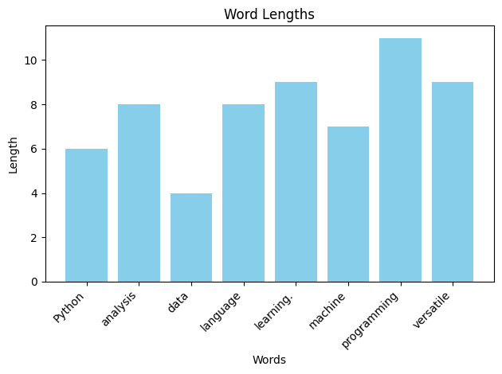

```python
import matplotlib.pyplot as plt

input_string = "Python is a versatile programming language for data analysis and machine learning."
Splittted_words = input_string.split()
print("String after splitted words:-",Splittted_words)
filtered_words = [word for word in Splittted_words if len(word) >= 4]
print("Words remaining after removing all words that have less than 4 charachters:-",filtered_words)
sorted_words = sorted(filtered_words)
print("After Sorting the remaining words alphabetically:-",sorted_words)



word_lengths = {word: len(word) for word in sorted_words}
plt.bar(word_lengths.keys(), word_lengths.values(), color='skyblue')
plt.title('Word Lengths')
plt.xlabel('Words')
plt.ylabel('Length')
plt.xticks(rotation=45, ha='right')
plt.tight_layout()
plt.show()
```

## Question 15: Anagram Finder:

Write a Python function to find all anagrams of a word in a given list.

```
Input: word = "listen", words = ["enlist", "google", "inlets", "banana"]

Output: ["enlist", "inlets"]
```

```python
def anagrams(word, word_list):
    sorted_word = sorted(word)
    anagrams = [w for w in word_list if sorted(w) == sorted_word]
    return anagrams

word = "listen"
words = ["enlist", "google", "inlets", "banana"]
result = anagrams(word, words)
print("Anagrams of",word,"in the list:",result)
```

```
Anagrams of listen in the list: ['enlist', 'inlets']
```

## Question 16: Set Operations:

- Given two lists, write Python code to find their intersection, union, and symmetric difference.
- Visualize the results using Venn diagrams.

```
The two sets are:-:
Set 1: [1, 2, 3, 4, 5]
Set 2: [4, 5, 6, 7, 8]
Intersection between two sets: {4, 5}
Union between two sets: {1, 2, 3, 4, 5, 6, 7, 8}
Symmetric Difference of two sets: {1, 2, 3, 6, 7, 8}
```

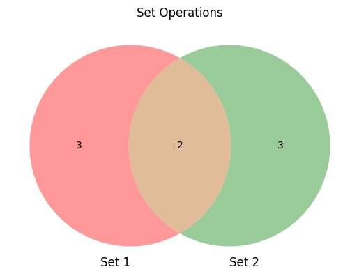

```python
from matplotlib_venn import venn2
import matplotlib.pyplot as plt

def set_operations(list1, list2):
    set1 = set(list1)
    set2 = set(list2)

    intersection = set1 & set2
    union = set1 | set2
    symmetric_difference = set1 ^ set2
    return intersection, union, symmetric_difference


list1 = [1, 2, 3, 4, 5]
list2 = [4, 5, 6, 7, 8]

intersection, union, symmetric_difference = set_operations(list1, list2)

print("The two sets are:-:")
print("Set 1:", list1)
print("Set 2:", list2)
print("Intersection between two sets:", intersection)
print("Union between two sets:", union)
print("Symmetric Difference of two sets:", symmetric_difference)

set1 = set(list1)
set2 = set(list2)
venn2([set1, set2], ('Set 1', 'Set 2'))
plt.title('Set Operations')
plt.show()
```

## Question 17: File Operations:

Write Python code to:

```
  - Create a text file.

  - Write a list of numbers to the file (one per line).

  - Read the file and compute their sum.
```

```python
def create_file(filename, numbers):
    with open(filename, 'w') as file:
        for number in numbers:
            file.write(f"{number}\n")

    total = 0
    with open(filename, 'r') as file:
        for line in file:
            total += int(line.strip())

    return total

filename = "numbers.txt"
numbers = [1, 2, 3, 4, 5,6,7,8,9,10]
total = create_file(filename, numbers)
print(f"The sum of the numbers in the file '{filename}' is: {total}")
```

```
The sum of the numbers in the file 'numbers.txt' is: 55
```

## Question 18: Word Count and Frequency:

Write a program to:

- Read a file and count the number of words in it.
- Find the most frequent word.
- Visualize the word frequencies using a bar chart.

```
Total number of words: 20
The words are:-['this', 'is', 'a', 'sample', 'program', 'in', 'python', 'and', 'this', 'is', 'realyy', 'fun', 'to', 'do', 'hello', 'worls', 'of', 'programming', 'in', 'python']
The most frequent word is 'this' with 2 occurrences.
```

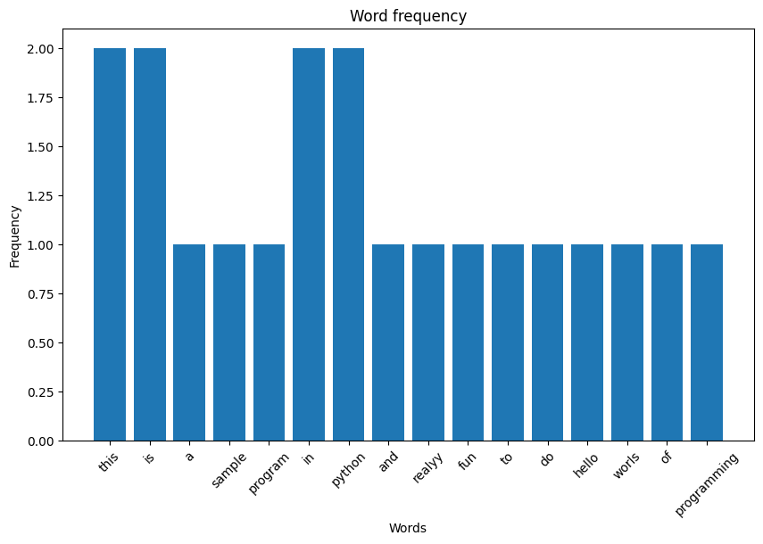

```python
import matplotlib.pyplot as plt
from collections import Counter
import re

def read_file(file_path):
    with open(file_path, 'r') as file:
        text = file.read()
    return text

def count_words(text):
    words = re.findall(r'\b\w+\b', text.lower())
    word_count = len(words)
    return word_count, words

def most_frequent_word(words):
    word_counter = Counter(words)
    most_common_word, frequency = word_counter.most_common(1)[0]
    return most_common_word, frequency, word_counter

def visualize_word_frequencies(word_counter):
    words, frequencies = zip(*word_counter.items())
    plt.figure(figsize=(10, 6))
    plt.bar(words, frequencies)
    plt.xlabel('Words')
    plt.ylabel('Frequency')
    plt.title('Word frequency')
    plt.xticks(rotation=45)
    plt.show()

def main(file_path):
    text = read_file(file_path)
    word_count, words = count_words(text)
    print(f"Total number of words: {word_count}")
    print(f"The words are:-{words}")

    most_common_word, frequency, word_counter = most_frequent_word(words)
    print(f"The most frequent word is '{most_common_word}' with {frequency} occurrences.")

    visualize_word_frequencies(word_counter)

file_path = '/content/My Text.txt'
main(file_path)
```

## Question 19: Random Number Generation:

Write a Python program to:

- Generate 100 random integers between 1 and 50.
- Save them in a text file, one per line.
- Read the file and compute the mean of the numbers.
- Visualize the distribution of the numbers using a histogram.

```
Mean of the numbers: 26.54
```

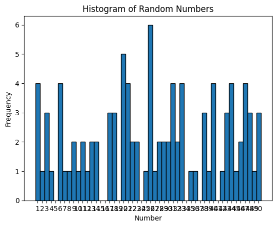

```python
import random
import matplotlib.pyplot as plt

def generate_random_numbers(file_path, count=100, start=1,end=50):
    random_numbers = [random.randint(start, end) for _ in range(count)]

    with open(file_path, 'w') as file:
        for number in random_numbers:
            file.write(f"{number}\n")

    return random_numbers

def read_numbers_from_file(file_path):
    with open(file_path, 'r') as file:
        numbers = [int(line.strip()) for line in file.readlines()]
    return numbers

def compute_mean(numbers):
    return sum(numbers) / len(numbers) if numbers else 0

def histogram(numbers):
    plt.hist(numbers, bins=range(1, 52), edgecolor='black', align='left')
    plt.xlabel('Number')
    plt.ylabel('Frequency')
    plt.title('Histogram of Random Numbers')
    plt.xticks(range(1, 51))
    plt.show()

file_path = 'random_numbers.txt'
random_numbers = generate_random_numbers(file_path)
numbers_from_file = read_numbers_from_file(file_path)
mean_value = compute_mean(numbers_from_file)
print(f"Mean of the numbers: {mean_value:.2f}")
histogram(numbers_from_file)
```

## Question 20: CSV File Operations:

- Write Python code to read a CSV file and compute the sum of values in a specific column.
- Visualize the data using a line plot.

```
The content of CSV file:-
     Name  Marks
0    Rosy     89
1   Rohit     90
2    Neha     78
3   Kriti      4
4   Kajol     43
5  Steven     35
6  Daniel     78
7  Denzel     70
Sum of the values in 'Marks': 487
```

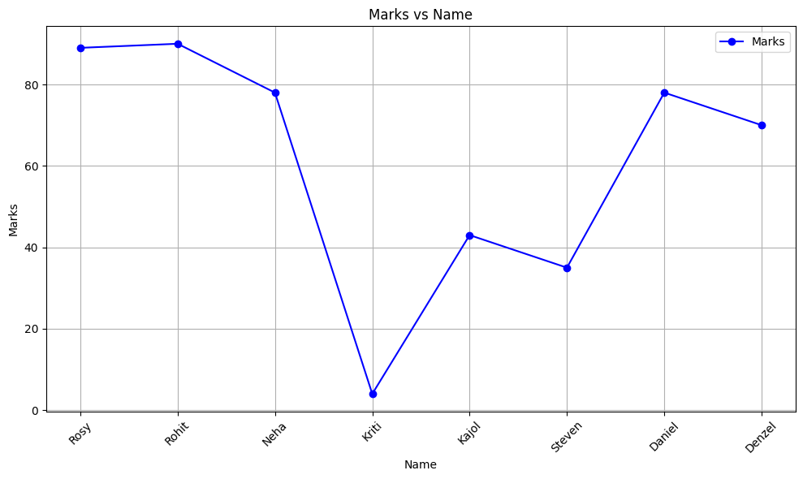

```python
import pandas as pd
import matplotlib.pyplot as plt

def read_csv_file(file_path):
    data = pd.read_csv(file_path)
    return data

def compute_column_sum(data, column_name):
    column_sum = data[column_name].sum()
    return column_sum

def visualize_data(data, column_name):
    column_one  = data.columns[0]
    column_two = data.columns[1]

    plt.figure(figsize=(10, 6))
    plt.plot(data[column_one], data[column_two], marker='o', linestyle='-', color='b', label=column_two)
    plt.xlabel(column_one)
    plt.ylabel(column_two)
    plt.title(f'{column_two} vs {column_one}')
    plt.xticks(rotation=45)
    plt.grid(True)
    plt.legend()
    plt.tight_layout()
    plt.show()


file_path = '/content/MyDataCSV.csv'
column_name = 'Marks'
data = read_csv_file(file_path)
print("The content of CSV file:-")
print(data)
column_sum = compute_column_sum(data, column_name)
print(f"Sum of the values in '{column_name}': {column_sum}")
visualize_data(data, column_name)
```

## Question 21: Basic Statistics:

Write Python code to calculate:

- Mean, median, mode, and standard deviation of a list of numbers.
- Visualize the data using a box plot.

```
Mean: 14.00
Median: 14
Mode: 14
Standard Deviation: 2.75
Visualizing using box plot:
```

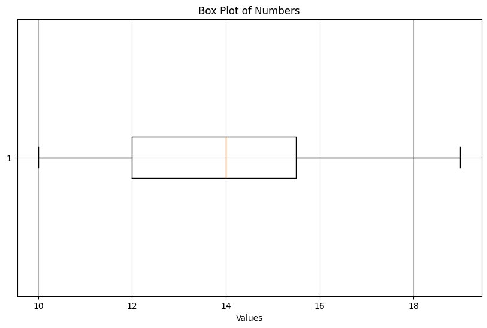

```python
import statistics as stats
import matplotlib.pyplot as plt

def calculate_statistics(numbers):
    mean_value = stats.mean(numbers)
    median_value = stats.median(numbers)
    mode_value = stats.mode(numbers)
    std_dev_value = stats.stdev(numbers)

    return mean_value, median_value, mode_value, std_dev_value

def visualize_data(numbers):
    plt.figure(figsize=(10, 6))
    plt.boxplot(numbers, vert=False)
    plt.xlabel('Values')
    plt.title('Box Plot of Numbers')
    plt.grid(True)
    plt.show()

numbers = [12, 15, 14, 10, 10, 17, 13, 14, 15, 18, 14, 12, 11, 16, 19]
mean_value, median_value, mode_value, std_dev_value = calculate_statistics(numbers)
print(f"Mean: {mean_value:.2f}")
print(f"Median: {median_value}")
print(f"Mode: {mode_value}")
print(f"Standard Deviation: {std_dev_value:.2f}")
print("Visualizing using box plot:")
visualize_data(numbers)
```

## Question 22: Normalization:

- Write a Python function to normalize a list of numbers to a range of 0 to 1.
- Visualize the normalized data using a line plot.

```
Normalized Data (Range 0 to 1): [0.2222222222222222, 0.5555555555555556, 0.4444444444444444, 0.0, 0.0, 0.7777777777777778, 0.3333333333333333, 0.4444444444444444, 0.5555555555555556, 0.8888888888888888, 0.4444444444444444, 0.2222222222222222, 0.1111111111111111, 0.6666666666666666, 1.0]
```

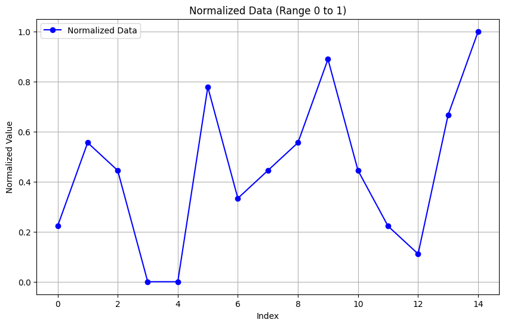

```python
import matplotlib.pyplot as plt

def normalize_data(numbers):
    min_val = min(numbers)
    max_val = max(numbers)
    normalized_numbers = [(x - min_val) / (max_val - min_val) for x in numbers]
    return normalized_numbers

def visualize_data(normalized_numbers):
    plt.figure(figsize=(10, 6))
    plt.plot(normalized_numbers, marker='o', linestyle='-', color='b', label='Normalized Data')
    plt.xlabel('Index')
    plt.ylabel('Normalized Value')
    plt.title('Normalized Data (Range 0 to 1)')
    plt.legend()
    plt.grid(True)
    plt.show()


numbers = [12, 15, 14, 10, 10, 17, 13, 14, 15, 18, 14, 12, 11, 16, 19]
normalized_numbers = normalize_data(numbers)
print("Normalized Data (Range 0 to 1):", normalized_numbers)
visualize_data(normalized_numbers)
```

## Question 23: Even or Odd:

- Write a Python program that takes an integer input from the user and prints whether the number is even or odd.

```python
def check_even_or_odd(num):
    if number % 2 == 0:
        print(f"The number {number} is even.")
    else:
        print(f"The number {number} is odd.")

number = int(input("Enter an integer: "))
result= check_even_or_odd(number)
```

```
Enter an integer: 13
The number 13 is odd.
```

## Question 24: Grade Calculator:

- Write a Python program that takes a numerical grade (0-100) as input and prints the corresponding letter grade (A, B, C, D, F).

```python
def Assign_grade(grade):
    if grade < 0 or grade > 100:
        print("Invalid input. Please enter a grade between 0 and 100.")
    else:
        if grade >= 90:
            letter_grade = 'A'
        elif grade >= 80:
            letter_grade = 'B'
        elif grade >= 70:
            letter_grade = 'C'
        elif grade >= 60:
            letter_grade = 'D'
        else:
            letter_grade = 'F'
        return letter_grade

grade = float(input("Enter a numerical grade (0-100): "))
Result=Assign_grade(grade)
print(f"The final grade assigned for marks {grade} is {Result}")
```

```
Enter a numerical grade (0-100): 100
The final grade assigned for marks 100.0 is A
```

## Question 25: Leap Year Checker:

- Write a Python program that takes a year as input and checks if it is a leap year.

```python
def leap_year(year):
  if (year % 4 == 0 and year % 100 != 0) or (year % 400 == 0):
        print(f"{year} is a leap year.")
  else:
        print(f"{year} is not a leap year.")

input_year = int(input("Enter a year: "))
leap_year(input_year)
```

```
Enter a year: 2029
2029 is not a leap year.
```